# bank_churn

## Predicting Bank Customer Churn

##### In this notebook, the task is to predict whether or not a customer will close his or her bank account (indicated by the target variable `Exited`) based on financial and demographic information. The dataset itself is simulated from an original real-world dataset such that the features have similar (but not identical) distributions. After processing the predictor variables, various ML models are fit on the data, from logistic regression to XGBoost. The final XGBoost model achieved a Kaggle competition-best ROC AUC score of $0.92868$ on the test set.

```python
import numpy as np
import pandas as pd
import matplotlib.pyplot as plt
from sklearn.model_selection import train_test_split, cross_validate, GridSearchCV
from sklearn.tree import DecisionTreeClassifier
from sklearn.linear_model import LogisticRegressionCV
from sklearn.ensemble import AdaBoostClassifier, RandomForestClassifier, BaggingClassifier
import xgboost
from xgboost import XGBClassifier
from sklearn.neighbors import KNeighborsClassifier
from sklearn.metrics import roc_auc_score, roc_curve
from sklearn.preprocessing import StandardScaler
import seaborn as sns

import warnings
warnings.filterwarnings("ignore")
```

### Load in and inspect the data

```python
df_train = pd.read_csv('train.csv')
df_test = pd.read_csv('test.csv')

df_train['dataset'] = 'train'
df_test['dataset'] = 'test'

df_all = pd.concat([df_train, df_test], ignore_index=True)
```

```python
display(df_all.head())
display(df_all.describe())
```

|  | id | CustomerId | Surname | CreditScore | Geography | Gender | Age | Tenure | Balance | NumOfProducts | HasCrCard | IsActiveMember | EstimatedSalary | Exited | dataset |
| --- | --- | --- | --- | --- | --- | --- | --- | --- | --- | --- | --- | --- | --- | --- | --- |
| 0 | 0 | 15778838.0 | Mazzanti | 582.0 | Germany | Female | 39.0 | 8.0 | 125534.51 | 1.0 | 1.0 | 0.0 | 131281.28 | 0.0 | train |
| 1 | 1 | 15788151.0 | Burtch | 744.0 | France | Female | 29.0 | 7.0 | 0.00 | 2.0 | 1.0 | 1.0 | 93829.17 | 0.0 | train |
| 2 | 2 | 15588928.0 | Frolov | 752.0 | Spain | Male | 32.0 | 3.0 | 0.00 | 2.0 | 0.0 | 0.0 | 125979.36 | 0.0 | train |
| 3 | 3 | 15694890.0 | Lu | 749.0 | Germany | Female | 54.0 | 7.0 | 82916.43 | 2.0 | 1.0 | 1.0 | 131736.23 | 0.0 | train |
| 4 | 4 | 15742841.0 | Macleod | 770.0 | Spain | Male | 43.0 | 2.0 | 0.00 | 2.0 | 1.0 | 0.0 | 157527.60 | 0.0 | train |

|  | id | CustomerId | CreditScore | Age | Tenure | Balance | NumOfProducts | HasCrCard | IsActiveMember | EstimatedSalary | Exited |
| --- | --- | --- | --- | --- | --- | --- | --- | --- | --- | --- | --- |
| count | 25000.000000 | 2.500000e+04 | 25000.000000 | 25000.000000 | 25000.000000 | 25000.000000 | 25000.00000 | 25000.00000 | 25000.000000 | 25000.000000 | 15000.000000 |
| mean | 12499.500000 | 1.569232e+07 | 658.432440 | 37.818120 | 5.031560 | 42796.704554 | 1.58992 | 0.78268 | 0.494720 | 117618.123325 | 0.205933 |
| std | 7217.022701 | 1.562388e+05 | 72.453969 | 8.207853 | 2.791716 | 59784.712943 | 0.52802 | 0.41243 | 0.499982 | 45690.982334 | 0.404395 |
| min | 0.000000 | 1.563152e+05 | 431.000000 | 18.000000 | 0.000000 | 0.000000 | 1.00000 | 0.00000 | 0.000000 | 11.580000 | 0.000000 |
| 25% | 6249.750000 | 1.563639e+07 | 603.000000 | 32.000000 | 3.000000 | 0.000000 | 1.00000 | 1.00000 | 0.000000 | 82709.800000 | 0.000000 |
| 50% | 12499.500000 | 1.569090e+07 | 661.000000 | 37.000000 | 5.000000 | 0.000000 | 2.00000 | 1.00000 | 0.000000 | 122960.980000 | 0.000000 |
| 75% | 18749.250000 | 1.575881e+07 | 709.000000 | 42.000000 | 7.000000 | 110153.270000 | 2.00000 | 1.00000 | 1.000000 | 156774.940000 | 0.000000 |
| max | 24999.000000 | 1.581569e+07 | 850.000000 | 74.000000 | 15.000000 | 208614.240000 | 4.00000 | 1.00000 | 1.000000 | 626144.090000 | 1.000000 |

### EDA

##### Let's take a closer look at the data. We will use a bar plot for categorical features and a histogram for numerical features.

##### The aim of this is two-fold: 1. Look at the values for different features in the dataset to ensure there is nothing that may impact resulting models (e.g., anomalous or seemingly incorrect data); and 2. Verify that the train and test sets have similar distributions, such that the former can be used to predict the latter

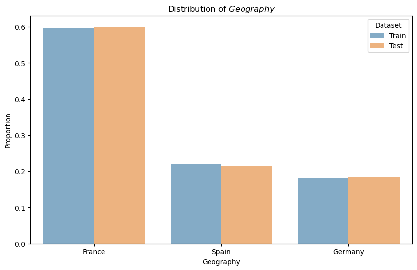

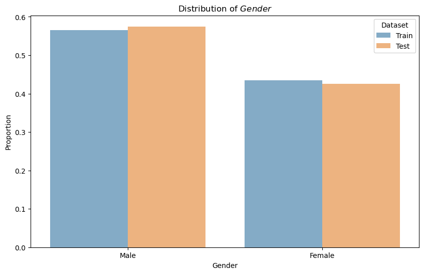

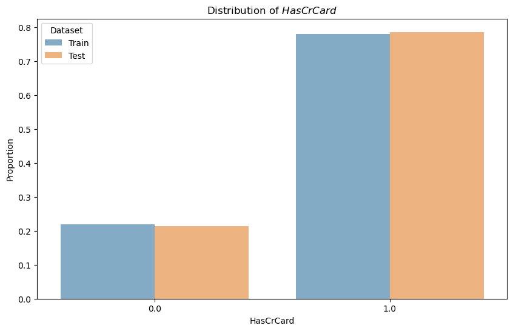

```python
def bar_plots(columns):
    for column in columns:
        plt.figure(figsize=(10, 6))

        combined_density = pd.concat([
            df_train[column].value_counts(normalize=True).rename('Proportion').reset_index().assign(Dataset='Train'),
            df_test[column].value_counts(normalize=True).rename('Proportion').reset_index().assign(Dataset='Test')
        ]).rename(columns={'index': column})

        sns.barplot(x=column, y='Proportion', hue='Dataset', data=combined_density, alpha=0.6)

        plt.title(fr'Distribution of ${column}$')
        plt.xlabel(column)
        plt.ylabel('Proportion')
        plt.legend(title='Dataset')
        plt.show()

bar_plots(['Geography', 'Gender', 'HasCrCard'])
```

[figure not shown]

[figure not shown]

[figure not shown]

```python
def hist_plots(df_all, columns):
    for column in columns:
        plt.figure(figsize=(10, 6))

        sns.histplot(data=df_all, x=column, hue='dataset', element='step', stat='density', common_norm=False, alpha=0.4)

        plt.title(rf'Distribution of ${column}$')
        plt.xlabel(column)
        plt.ylabel('Density')
        plt.show()

hist_plots(df_all, ['EstimatedSalary', 'Balance', 'CreditScore'])
```

[output not shown]

These plots assure us that the data are similarly distributed between the train and tests, thus serving as a green-light for subsequent modeling.

Also, because of the stark divide between people with low and high balances, at around `Balance` = 25,000, we create a new binary variable, `LowBalance`, with this cut-off.

```python
df_all['LowBalance'] = (df_all['Balance'] < 25000).astype(int)
```

### Preprocessing

##### Now we will process the data to get it into a format that can be handled by ML models. Namely, categorical columns will be one-hot encoded and numerical columns will be standardized.

```python
cat_cols = ['Geography', 'Gender', 'HasCrCard', 'IsActiveMember']
num_cols = ['CreditScore', 'Age', 'Tenure', 'Balance', 'NumOfProducts', 'EstimatedSalary']
```

```python
df_all = pd.get_dummies(df_all, columns=cat_cols)
```

```python
scaler = StandardScaler()
df_all[num_cols] = scaler.fit_transform(df_all[num_cols])
```

```python
X_train = df_all[df_all['dataset'] == 'train'].drop(columns=['dataset', 'Exited', 'id', 'CustomerId', 'Surname'])
y_train = df_all[df_all['dataset'] == 'train']['Exited']
X_test_ids = df_all[df_all['dataset'] == 'test'].id
X_test = df_all[df_all['dataset'] == 'test'].drop(columns=['dataset', 'id', 'Exited', 'CustomerId', 'Surname'])

X_train_full = X_train.copy()
y_train_full = y_train.copy()

X_train, X_val, y_train, y_val = train_test_split(X_train, y_train, test_size=.2, random_state=0, stratify=y_train)
```

##### The below heatmap shows the pairwise correlations between the variables in the dataset. We are most interested in seeing how correlated the predictor variables are to `Exited`, as this indicates that they have predictive potential. Fortunately, as seen in the bottom row, such is the case for many predictors, with `Age` being the most correlated.

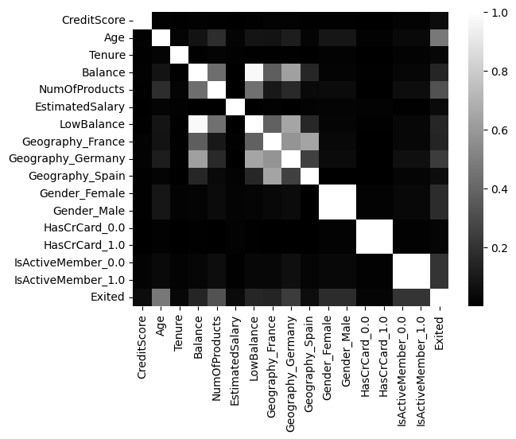

```python
sns.heatmap(pd.concat([X_train, y_train], axis=1).corr().abs(), cmap='gray')
plt.show()
```

## Models

### Logistic Regression

```python
Cs = [1e-4,1e-3,1e-2,1e-1,1e0,1e1,1e2,1e3,1e4]
logistic = LogisticRegressionCV(
    Cs=Cs, cv=4, penalty='l1', solver='liblinear', scoring='roc_auc'
).fit(X_train_full, y_train_full)
```

```python
logistic.C_
```

```
array([0.1])
```

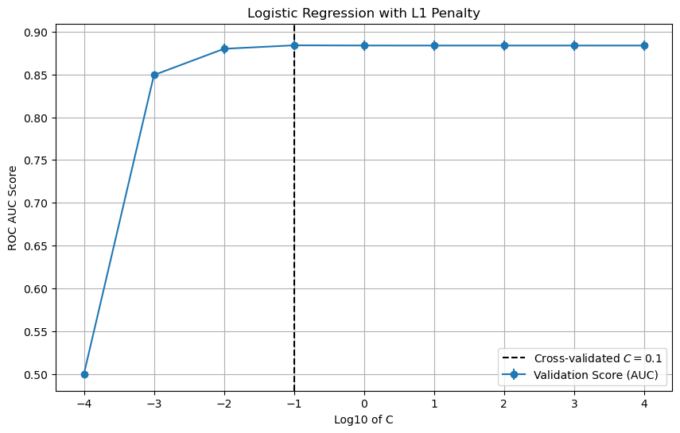

```python
cv_scores = logistic.scores_[1]

# Calculate mean and standard deviation of scores for each C
mean_cv_scores = np.mean(cv_scores, axis=0)
std_cv_scores = np.std(cv_scores, axis=0)

# Plotting
plt.figure(figsize=(10, 6))
plt.errorbar(np.log10(Cs), mean_cv_scores, yerr=std_cv_scores, label='Validation Score (AUC)', fmt='-o')
plt.axvline(np.log10(logistic.C_[0]), linestyle='--', color='black', label=rf'Cross-validated $C={logistic.C_[0]}$')
plt.xlabel('Log10 of C')
plt.ylabel('ROC AUC Score')
plt.title('Logistic Regression with L1 Penalty')
plt.legend()
plt.grid(True)
plt.show()
```

```python
# Function to save predictions for submission in competition
def get_submission(model, model_name=''):
    pred_probas = model.predict_proba(X_test)[:, 1]
    preds_df = pd.DataFrame({
        'id': X_test_ids,
        'Exited': pred_probas
    }).set_index('id')
    if model_name:
        model_name = model_name + '_'
    preds_df.to_csv(f'predictions/{model_name}predictions.csv')
```

```python
get_submission(logistic, 'logistic')
```

### kNN

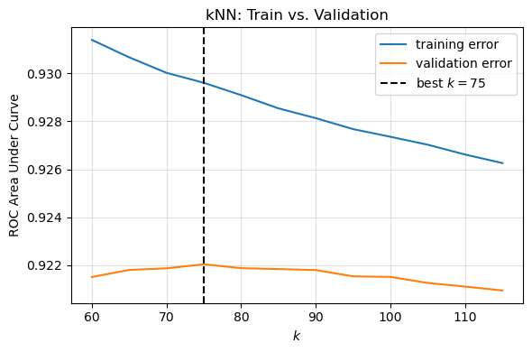

```python
ks = list(range(60,120,5))
cv = 5

results = []
training_error = []
validation_error = []
validation_std = []

for k in ks:
    knn = KNeighborsClassifier(k)
    knn_cv = cross_validate(knn, X_train_full, y_train_full, cv=cv, scoring='roc_auc', return_train_score=True)
    training_error.append(np.mean(knn_cv['train_score']))
    validation_error.append(np.mean(knn_cv['test_score']))
    validation_std.append(np.std(knn_cv['test_score']))

best_k = ks[np.argmax(validation_error)]

fig, ax = plt.subplots(figsize=(6,4))

ax.plot(ks, training_error, label='training error');
ax.plot(ks, validation_error, label='validation error');

ax.set_xlabel(r'$k$', fontsize=10)
ax.set_ylabel('ROC Area Under Curve', fontsize=10)
ax.axvline(best_k, color='black', linestyle='--', label=rf'best $k={best_k}$')
ax.set_title('kNN: Train vs. Validation', fontsize=12)
ax.grid(":", alpha=0.4)

ax.legend(loc='best')
plt.tight_layout()
```

```python
best_knn = KNeighborsClassifier(best_k).fit(X_train_full, y_train_full)
```

```python
get_submission(best_knn, 'knn')
```

### Decision Tree

```python
single_tree = GridSearchCV(estimator=DecisionTreeClassifier(random_state=109),
                  param_grid={'min_samples_split': range(3,15), 'max_depth': range(3,10)},
                  cv=5,
                  scoring='roc_auc',
                  n_jobs=-1)
single_tree.fit(X_train_full, y_train_full);
```

```python
best_max_depth = single_tree.best_params_['max_depth']
best_min_samples = single_tree.best_params_['min_samples_split']
single_tree.best_params_
best_tree = single_tree.best_estimator_
```

### Bagging

```python
depths = range(3, 10)
min_samples_splits = range(3,7)
train_scores = []
oob_scores = []
best_params = {}
best_oob_score = 0

for i, depth in enumerate(depths):
    for j, min_samples in enumerate(min_samples_splits):
        bagger = BaggingClassifier(estimator=DecisionTreeClassifier(min_samples_split=min_samples, max_depth = depth), oob_score=True)
        bagger.fit(X_train_full, y_train_full)
        train_scores.append(bagger.score(X_train_full, y_train_full))
        oob_scores.append(bagger.oob_score_)

        if bagger.oob_score_ > best_oob_score:
            best_oob_score = bagger.oob_score_
            best_params['depth'] = depth
            best_params['min_samples_split'] = min_samples
```

```python
best_depth = best_params['depth']
best_min_samples = best_params['min_samples_split']
print(f"best_depth: {best_depth}\nbest_min_samples: {best_min_samples}")
```

```
best_depth: 6
best_min_samples: 5
```

##### Rather than using cross-validation, we can use the out-of-bag (OOB) errors, calculated by testing individual trees on data points that they did not see during training. This occurs since each tree is fit on a bootstrapped dataset.

```python
bag = BaggingClassifier(estimator=DecisionTreeClassifier(min_samples_split=best_min_samples, max_depth=best_depth), oob_score=True)
max_estimators = 50
train_scores = np.zeros(max_estimators)
oob_scores = np.zeros_like(train_scores)
for i, n in enumerate(range(1, max_estimators+1)):
    bag.n_estimators = n
    bag.fit(X_train, y_train)
    train_scores[i] = bag.score(X_train, y_train)
    oob_scores[i] = bag.oob_score_
```

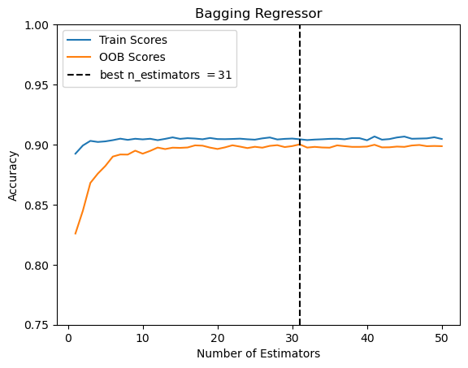

```python
# Visualize the plateau as n_estimators increases (and select the best)
plt.plot(range(1, max_estimators+1),
         train_scores,
         label = 'Train Scores')
plt.plot(range(1, max_estimators+1),
         oob_scores,
         label='OOB Scores')
best_idx = oob_scores.argmax()
best_n_estimators = best_idx + 1
plt.axvline(best_n_estimators, color='black', linestyle='--', label = rf'best n_estimators $= {best_n_estimators}$')
plt.title('Bagging Regressor')
plt.xlabel('Number of Estimators')
plt.ylabel('Accuracy')
plt.ylim(.75,1)
plt.legend();
```

```python
best_bagger = BaggingClassifier(estimator=DecisionTreeClassifier(min_samples_split=best_min_samples, max_depth=best_depth),
                                n_estimators=best_n_estimators
                                ).fit(X_train_full, y_train_full)
```

```python
get_submission(best_bagger, 'bagging')
```

### Random Forest

```python
rf_cv = GridSearchCV(estimator=RandomForestClassifier(random_state=109),
                  param_grid={'min_samples_split': [6,7,8,9], 'max_features': [3,4,5]},
                  cv=5)
rf_cv.fit(X_train_full, y_train_full);
```

```python
best_min_samples = rf_cv.best_params_['min_samples_split']
best_max_feautures = rf_cv.best_params_['max_features']
print(f"best_min_samples: {best_min_samples}\nbest_max_feautures: {best_max_feautures}")
```

```
best_min_samples: 9
best_max_feautures: 3
```

```python
best_rf = RandomForestClassifier(min_samples_split=best_min_samples, max_features=best_max_feautures, random_state=109
                                 ).fit(X_train_full, y_train_full)
```

##### We can also use the built in `feature_importances_` attribute to rank the features based on how much they decreased the impurity of the decision trees that make up the random forest. This allows us to take a look under the hood and build some intuition on what customer attributes and behaviors serve as the best predictors for churn.

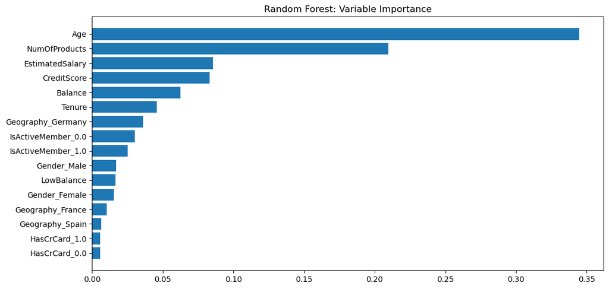

```python
importances = best_rf.feature_importances_

fig, ax = plt.subplots(figsize=(12,6))
order = np.argsort(importances)
ax.barh(range(len(importances)), importances[order], tick_label=X_train.columns[order]);
ax.set_title(f"Random Forest: Variable Importance")
fig.show()
```

```python
get_submission(best_rf, 'rf')
```

### AdaBoost

```python
# Find the best learning rate
lrs = [.025, .05, .1, .2]
depth = 2
n_estimators = 1000
best_val_scores = {}
val_auc_scores = {}
for lr in lrs:
    ada = AdaBoostClassifier(estimator=DecisionTreeClassifier(max_depth=2), n_estimators=n_estimators, learning_rate=lr, random_state=109).fit(X_train, y_train)
    val_auc_scores[lr] = []
    for stage_pred_probas in ada.staged_predict_proba(X_val):
        auc_score = roc_auc_score(y_val, stage_pred_probas[:, 1])
        val_auc_scores[lr].append(auc_score)
    # Score the best validation score and its number of estimators for a given learning rate
    best_stage_ix = np.argmax(val_auc_scores[lr])
    best_val_scores[lr] = (best_stage_ix + 1, val_auc_scores[lr][best_stage_ix])
```

```python
best_lr = max(best_val_scores, key=lambda k: best_val_scores[k][1])
best_n_estimators, best_score = best_val_scores[best_lr]
print(f"best_lr: {best_lr}\nbest_n_estimators: {best_n_estimators}\nbest_score: {best_score:.2}")
```

```
best_lr: 0.05
best_n_estimators: 197
best_score: 0.92
```

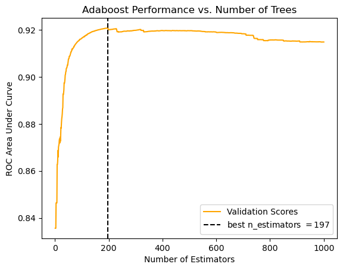

```python
plt.plot(range(1, n_estimators+1),
         val_auc_scores[best_lr],
         color='orange',
         label = 'Validation Scores')
best_n_estimators = np.argmax(val_auc_scores[best_lr]) + 1
plt.axvline(best_n_estimators, color='black', linestyle='--', label = rf'best n_estimators $= {best_n_estimators}$')
plt.title('Adaboost Performance vs. Number of Trees')
plt.xlabel('Number of Estimators')
plt.ylabel('ROC Area Under Curve')
plt.legend();
```

```python
best_ada = AdaBoostClassifier(estimator=DecisionTreeClassifier(max_depth=depth),
                              learning_rate=best_lr, n_estimators=best_n_estimators, random_state=109
                              ).fit(X_train_full, y_train_full)
```

```python
get_submission(best_ada, 'ada')
```

### XGBoost

##### First we fit a preliminary model with intuitively selected hyperparameters to get a sense of XGBoost's potential.

```python
# Preliminary model
xgb = XGBClassifier(objective='binary:logistic',
                    eval_metric=roc_auc_score,
                    n_estimators=1000,
                    max_depth=3,
                    learning_rate=0.1,
                    random_state=0)

xgb.fit(X_train, y_train,
        eval_set=[(X_val, y_val)],
        verbose=False);
```

```python
# Extract the predictions with the best ROC AUC score
roc_auc_scores = xgb.evals_result()['validation_0']['roc_auc_score']
best_iteration = np.argmax(roc_auc_scores)
print(f"best_iteration: {best_iteration}")
print(f"ROC AUC Score: {roc_auc_score(y_val, xgb.predict_proba(X_val, iteration_range=(0,best_iteration+1))[:,1]):.4f}")
```

```
best_iteration: 109
ROC AUC Score: 0.9230
```

```python
# Train preliminay model on the full training set
xgb = XGBClassifier(objective='binary:logistic',
                    eval_metric=roc_auc_score,
                    n_estimators=best_iteration+1,
                    max_depth=3,
                    learning_rate=0.1,
                    random_state=0)

xgb.fit(X_train_full, y_train_full, verbose=False);
```

```python
get_submission(xgb, 'xgb_prelim')
```

##### Now, we take a more structured approach by finding the best `max_depth` and `learning_rate` hyperaparameters with 5-fold cross-validation.

##### We also use early stopping since, unlike bagging or random forests, boosting models will overfit if they are trained for too many iterations (as seen in the Adaboost plot above). Early stopping will automatically save the model iteration and its hyperparameters that resulted in the best score on the validation set. We use the ROC AUC score, as this is the metric used for the Kaggle competition.

```python
# Grid search cross validation with early stopping
param_grid = {
    'max_depth': [1, 2, 3, 4],
    'learning_rate': [0.05, 0.1, 0.15, .2]
}

es = xgboost.callback.EarlyStopping(
    rounds=10,
    min_delta=1e-3,
    save_best=True,
    maximize=True,
    data_name="validation_0",
)

xgb_cv = XGBClassifier(objective='binary:logistic',
                       eval_metric=roc_auc_score,
                       n_estimators=1000,
                       random_state=0,
                       callbacks=[es])

grid_search = GridSearchCV(estimator=xgb_cv, param_grid=param_grid, cv=5, scoring='roc_auc', return_train_score=True)
grid_search.fit(X_train, y_train, eval_set=[(X_val, y_val)], verbose=False);
```

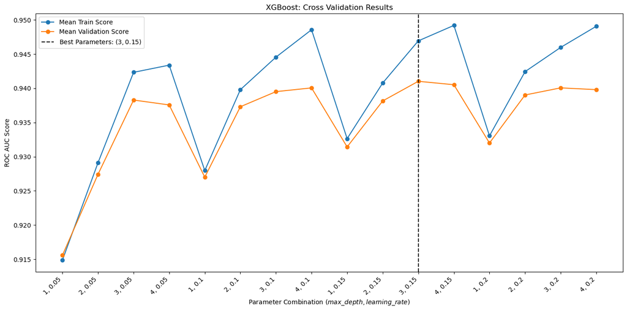

```python
results = pd.DataFrame(grid_search.cv_results_)

# Extract mean training and validation scores for each parameter combination
mean_train_scores = results['mean_train_score']
mean_test_scores = results['mean_test_score']
params = results['param_max_depth'].astype(str) + ', ' + results['param_learning_rate'].astype(str)

# Plot the results
plt.figure(figsize=(14, 7))
plt.plot(params, mean_train_scores, label='Mean Train Score', marker='o')
plt.plot(params, mean_test_scores, label='Mean Validation Score', marker='o')

# Add titles and labels
plt.title('XGBoost: Cross Validation Results')
plt.xlabel(rf'Parameter Combination $(max\_depth, learning\_rate)$')
plt.ylabel('ROC AUC Score')
plt.axvline(params[10], linestyle='--', color='black', label=f'Best Parameters: $({params[10]})$')
plt.xticks(rotation=45, ha='right')
plt.legend()
plt.tight_layout()
plt.show()
```

```python
print("Best iteration:", grid_search.best_estimator_.best_iteration)
print("Best Parameters:", grid_search.best_params_)
print(f"Best Validation ROC AUC Score: {grid_search.best_score_:.4f}")
```

```
Best iteration: 50
Best Parameters: {'learning_rate': 0.15, 'max_depth': 3}
Best Validation ROC AUC Score: 0.9410
```

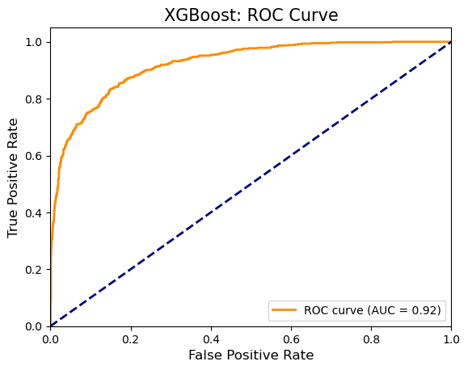

```python
# Compute the ROC curve and ROC area
y_pred_proba = grid_search.best_estimator_.predict_proba(X_val)[:, 1]
fpr, tpr, _ = roc_curve(y_val, y_pred_proba)
roc_auc = roc_auc_score(y_val, y_pred_proba)

# Plot ROC curve
plt.figure()
plt.plot(fpr, tpr, color='darkorange', lw=2, label=f'ROC curve (AUC = {roc_auc:.2f})')
plt.plot([0, 1], [0, 1], color='navy', lw=2, linestyle='--')
plt.xlim([0.0, 1.0])
plt.ylim([0.0, 1.05])
plt.xlabel('False Positive Rate', fontsize=12)
plt.ylabel('True Positive Rate', fontsize=12)
plt.title('XGBoost: ROC Curve', fontsize=15)
plt.legend(loc='lower right')
plt.show()
```

##### Now that we've identified the best hyperparameters, we will train our final XGBoost model on the *full* training set (i.e., training + validation)

```python
# Fit the final XGB model
best_iteration = grid_search.best_estimator_.best_iteration + 1
best_lr = grid_search.best_params_['learning_rate']
best_depth = grid_search.best_params_['max_depth']

best_xgb = XGBClassifier(objective='binary:logistic',
                         n_estimators=best_iteration,
                         max_depth=best_depth,
                         learning_rate=best_lr,
                         random_state=0)

best_xgb.fit(X_train_full, y_train_full, verbose=False);
```

```python
get_submission(best_xgb, 'xgb')
```

##### This model's predictions achieved an ROC AUC score of $0.92868$ on the withheld test set, securing its position as the winner of the competition. (The calculations cannot be shown here as they were done separately through Kaggle).